# Homework (Chapter 7)

Hwang Seong-Yun

2020 11 20

## packages

```r
library(tidyverse)
library(survival)
library(KMsurv)
library(survminer)
```

## 연습문제 7-2) 일차성 담즙성 간경화증(Primary Biliary Cirrhoris: PBC) 데이터에 대해 Cox 비례위험모형을 적합하고자 한다. PBC 데이터는 survival 패키지에 내장되어 있다. 일차성 담즙성 간경화증은 자가면역질환에 해당하며 담즙정체에 의해서 간에 경화가 오는 것으로 고간질환이다. 담관(Bile duct)이 폐쇄되어 부드러운 간 조직이 단단하게 되어 피부색이 노랗게 변하는 황달이 함께 나타나는 질환이다. 데이터는 1974년부터 1984년까지 미국 Mayo clinic에서 치료받은 418명 환자들로 구성된다. 고정 공변량으로는 환자의 나이, bilirubin(담즙구성 성분), albumin(수용성 혈장성분), prothrombin(피 응고까지 걸리는 시간), edema(상태, 0, 0.5, 1=심각), time(환자의 사망까지의 시간)이다. bilirubin과 prothrombin 변수는 비대칭 정도가 심각하여 로그변환을 적용한다. 환자상태를 나타내는 중도절단변수는 status이며 사망(status=2), 간 이식(liver transplant=1)을 의미한다. ascites는 ascties(복수, 복막강에 액체가 고인 상태)에 대한 존재여부(0=no, 1=yes)이다.

```r
data(pbc)
head(pbc)
```

```
##   id time status trt      age sex ascites hepato spiders edema bili chol
## 1  1  400      2   1 58.76523   f       1      1       1   1.0 14.5  261
## 2  2 4500      0   1 56.44627   f       0      1       1   0.0  1.1  302
## 3  3 1012      2   1 70.07255   m       0      0       0   0.5  1.4  176
## 4  4 1925      2   1 54.74059   f       0      1       1   0.5  1.8  244
## 5  5 1504      1   2 38.10541   f       0      1       1   0.0  3.4  279
## 6  6 2503      2   2 66.25873   f       0      1       0   0.0  0.8  248
##   albumin copper alk.phos    ast trig platelet protime stage
## 1    2.60    156   1718.0 137.95  172      190    12.2     4
## 2    4.14     54   7394.8 113.52   88      221    10.6     3
## 3    3.48    210    516.0  96.10   55      151    12.0     4
## 4    2.54     64   6121.8  60.63   92      183    10.3     4
## 5    3.53    143    671.0 113.15   72      136    10.9     3
## 6    3.98     50    944.0  93.00   63       NA    11.0     3
```

```r
attach(pbc)
```

### (1) 환자의 사망시간 데이터에 대해 age(환자의 나이), log(bilirubin), log(protime), albumin, edena를 공변량으로 하는 Cox 비례위험모형을 적합하고 회귀계수의 유의성과 모형에 대해 해석하시오.

### (2) (1)에서 구한 모형에 대해 각 공변량이 1 단위 증가할 때 위험률의 증감을 설명하시오.

```r
pbc$logbili <- log(pbc$bili) ; pbc$logprotime <- log(pbc$protime)
pbc$censor <- as.numeric((pbc$status==2))
attach(pbc)
Surv(time, censor)
```

[output not shown]

[output cut: 20 more lines]

```r
fit <- coxph(Surv(time,censor)~age+logbili+logprotime+albumin+edema,ties="efron",data=pbc)
summary(fit)
```

```
## Call:
## coxph(formula = Surv(time, censor) ~ age + logbili + logprotime +
##     albumin + edema, data = pbc, ties = "efron")
##
##   n= 416, number of events= 160
##    (2 observations deleted due to missingness)
##
##                 coef exp(coef)  se(coef)      z Pr(>|z|)
## age         0.039713  1.040512  0.007655  5.188 2.12e-07 ***
## logbili     0.862491  2.369054  0.083026 10.388  < 2e-16 ***
## logprotime  2.373164 10.731297  0.767849  3.091 0.001997 **
## albumin    -0.756712  0.469207  0.209116 -3.619 0.000296 ***
## edema       0.902100  2.464774  0.271733  3.320 0.000901 ***
## ---
## Signif. codes:  0 '***' 0.001 '**' 0.01 '*' 0.05 '.' 0.1 ' ' 1
##
##            exp(coef) exp(-coef) lower .95 upper .95
## age           1.0405    0.96107    1.0250    1.0562
## logbili       2.3691    0.42211    2.0133    2.7877
## logprotime   10.7313    0.09319    2.3826   48.3333
## albumin       0.4692    2.13126    0.3114    0.7069
## edema         2.4648    0.40572    1.4470    4.1983
##
## Concordance= 0.835  (se = 0.017 )
## Likelihood ratio test= 230.1  on 5 df,   p=<2e-16
## Wald test            = 232.6  on 5 df,   p=<2e-16
## Score (logrank) test = 299.1  on 5 df,   p=<2e-16
```

### (3) 복수(ascites)가 있는지 여부에 대한 변수를 층 변수로 하여 edema, log(bilirubin), log(protime), log(albumin)을 포함한 비례위험모형을 적합하시오.

```r
pbc$logalbumin <- log(pbc$albumin)
attach(pbc)
fit1 <- coxph(Surv(time,censor)~edema+logbili+logprotime+logalbumin+strata(ascites),ties="efron",data=pbc)
summary(fit1)
```

```
## Call:
## coxph(formula = Surv(time, censor) ~ edema + logbili + logprotime +
##     logalbumin + strata(ascites), data = pbc, ties = "efron")
##
##   n= 312, number of events= 125
##    (106 observations deleted due to missingness)
##
##                coef exp(coef) se(coef)      z Pr(>|z|)
## edema       0.57787   1.78223  0.31593  1.829  0.06739 .
## logbili     0.83078   2.29512  0.10215  8.133 4.18e-16 ***
## logprotime  3.35393  28.61503  1.04777  3.201  0.00137 **
## logalbumin -3.11469   0.04439  0.78863 -3.949 7.83e-05 ***
## ---
## Signif. codes:  0 '***' 0.001 '**' 0.01 '*' 0.05 '.' 0.1 ' ' 1
##
##            exp(coef) exp(-coef) lower .95 upper .95
## edema        1.78223    0.56109  0.959495    3.3104
## logbili      2.29512    0.43571  1.878697    2.8038
## logprotime  28.61503    0.03495  3.670574  223.0769
## logalbumin   0.04439   22.52634  0.009463    0.2083
##
## Concordance= 0.809  (se = 0.024 )
## Likelihood ratio test= 134.8  on 4 df,   p=<2e-16
## Wald test            = 136.3  on 4 df,   p=<2e-16
## Score (logrank) test = 155.9  on 4 df,   p=<2e-16
```

#### 분석결과, 유의수준 0.1 기준으로 4가지 공변량 모두 환자의 사망위험률에 대해 유의한 영향력을 미치는 것으로 나타났다. 그리고 log(albumin)을 제외한 3가지 공변량(edema, log(bilirubin), log(protime))은 그 값이 1단위(edema는 0.5단위) 증가할 때마다 환자의 사망위험률이 증가함을 알 수 있다.

## 연습문제 7-3) 다음은 F98 glioma(신경교종 : 중추신경의 신경교조직에서 발생하는 종양) 치료에 boron neutron capture therapy(BNCT : 붕소 중성자 치료)의 효과를 알아보기 위한 연구 결과이다. 실험쥐를 세 그룹으로 랜덤하게 배정한 후 각 실험쥐의 뇌에 F98 glioma cell을 이식한 후 사망까지의 시간 데이터이다. 처리하지 않은 대조 그룹, 방사선을 쪼인 그룹, 방사선요법과 boronophenylanine(BPA)를 같이 처리한 그룹에 대해 실험한 결과는 다음과 같다.

```r
detach(pbc)
BPA <- tibble(time=c(20,21,23,24,24,26,26,27,28,30,26,28,29,30,30,31,31,32,29,35,31,32,34,35,36,38,38,42,39,42),censor=c(rep(1,10),rep(1,9),0,rep(1,7),0,rep(1,2)),method=c(rep("untreated",10),rep("radiated",10),rep("radiated+BPA",10)))
BPA
```

```
## # A tibble: 30 x 3
##     time censor method
##    <dbl>  <dbl> <chr>
##  1    20      1 untreated
##  2    21      1 untreated
##  3    23      1 untreated
##  4    24      1 untreated
##  5    24      1 untreated
##  6    26      1 untreated
##  7    26      1 untreated
##  8    27      1 untreated
##  9    28      1 untreated
## 10    30      1 untreated
## # ... with 20 more rows
```

### (1) 다음과 같은 그룹을 표시할 수 있는 가변수(dummy variable)를 다음과 같이 만들었다.

### Z1 = 1(radiated only) / 0(otherwise)

### Z2 = 1(radiation+BPA) / 0(otherwise)

### untreated 그룹은 Z1, Z2를 이용할 경우 어떻게 표시될 수 있는가?

#### untreated 그룹은 Z1, Z2의 값이 모두 0일 경우이다.

```r
BPA <- tibble(time=c(20,21,23,24,24,26,26,27,28,30,26,28,29,30,30,31,31,32,29,35,31,32,34,35,36,38,38,42,39,42),censor=c(rep(1,10),rep(1,9),0,rep(1,7),0,rep(1,2)),method=c(rep("untreated",10),rep("radiated",10),rep("radiated+BPA",10)),Z1=c(rep(0,10),rep(1,10),rep(0,10)),Z2=c(rep(0,20),rep(1,10)))
BPA
```

```
## # A tibble: 30 x 5
##     time censor method       Z1    Z2
##    <dbl>  <dbl> <chr>     <dbl> <dbl>
##  1    20      1 untreated     0     0
##  2    21      1 untreated     0     0
##  3    23      1 untreated     0     0
##  4    24      1 untreated     0     0
##  5    24      1 untreated     0     0
##  6    26      1 untreated     0     0
##  7    26      1 untreated     0     0
##  8    27      1 untreated     0     0
##  9    28      1 untreated     0     0
## 10    30      1 untreated     0     0
## # ... with 20 more rows
```

### (2) Z1을 공변량으로 하는 비례위험모형을 적합하고 해석하시오.

```r
attach(BPA)
fit <- coxph(Surv(time,censor)~Z1,ties="efron",data=BPA)
summary(fit)
```

```
## Call:
## coxph(formula = Surv(time, censor) ~ Z1, data = BPA, ties = "efron")
##
##   n= 30, number of events= 28
##
##      coef exp(coef) se(coef)     z Pr(>|z|)
## Z1 0.3190    1.3757   0.4387 0.727    0.467
##
##    exp(coef) exp(-coef) lower .95 upper .95
## Z1     1.376     0.7269    0.5822     3.251
##
## Concordance= 0.498  (se = 0.05 )
## Likelihood ratio test= 0.52  on 1 df,   p=0.5
## Wald test            = 0.53  on 1 df,   p=0.5
## Score (logrank) test = 0.53  on 1 df,   p=0.5
```

#### 분석결과를 통해 방사선요법만을 실시한 그룹이 그렇지 않은 경우에 비해 사망위험률이 약 1.376배로 증가하는 것으로 보여진다. 하지만 그 결과는 유의수준이 0.1인 경우 통계적으로 유의하지는 않다.

### (3) Z2를 공변량으로 하는 비례위험모형을 적합하고 해석하시오.

```r
fit1 <- coxph(Surv(time,censor)~Z2,ties="efron",data=BPA)
summary(fit1)
```

```
## Call:
## coxph(formula = Surv(time, censor) ~ Z2, data = BPA, ties = "efron")
##
##   n= 30, number of events= 28
##
##       coef exp(coef) se(coef)      z Pr(>|z|)
## Z2 -2.1506    0.1164   0.5857 -3.672 0.000241 ***
## ---
## Signif. codes:  0 '***' 0.001 '**' 0.01 '*' 0.05 '.' 0.1 ' ' 1
##
##    exp(coef) exp(-coef) lower .95 upper .95
## Z2    0.1164       8.59   0.03694    0.3669
##
## Concordance= 0.718  (se = 0.032 )
## Likelihood ratio test= 17.95  on 1 df,   p=2e-05
## Wald test            = 13.48  on 1 df,   p=2e-04
## Score (logrank) test = 17.01  on 1 df,   p=4e-05
```

#### 분석결과를 통해 방사선요법과 BPA를 모두 실시한 그룹이 그렇지 않은 경우에 비해 사망위험률이 약 0.1164배로 감소하는 것으로 보여진다. 그리고 그 결과는 유의수준이 0.1인 경우 통계적으로 유의하다.

### (4) Z1, Z2를 공변량으로 하는 비례위험모형을 적합하고 해석하시오.

### (5) 비례위험모형에서 그룹효과가 있는지 유의수준 0.05에서 검정하시오.

```r
fit2 <- coxph(Surv(time,censor)~Z1+Z2,ties="efron",data=BPA)
summary(fit2)
```

```
## Call:
## coxph(formula = Surv(time, censor) ~ Z1 + Z2, data = BPA, ties = "efron")
##
##   n= 30, number of events= 28
##
##        coef exp(coef) se(coef)      z Pr(>|z|)
## Z1 -1.92238   0.14626  0.56670 -3.392 0.000693 ***
## Z2 -3.76323   0.02321  0.76612 -4.912 9.01e-07 ***
## ---
## Signif. codes:  0 '***' 0.001 '**' 0.01 '*' 0.05 '.' 0.1 ' ' 1
##
##    exp(coef) exp(-coef) lower .95 upper .95
## Z1   0.14626      6.837   0.04817    0.4441
## Z2   0.02321     43.087   0.00517    0.1042
##
## Concordance= 0.818  (se = 0.018 )
## Likelihood ratio test= 29.93  on 2 df,   p=3e-07
## Wald test            = 24.52  on 2 df,   p=5e-06
## Score (logrank) test = 35.2  on 2 df,   p=2e-08
```

#### 분석결과를 통해 방사선요법만을 실시한 그룹은 대조군에 비해 사망위험률이 약 0.146배로 감소하는 것으로 보여지고, 방사선요법과 BPA를 모두 실시한 그룹은 대조군에 비해 사망위험률이 약 0.023배로 감소하는 것으로 보여지고 있다. 그리고 그 결과는 유의수준이 0.05인 경우 모두 통계적으로 유의하다.

#### 또한 분석결과의 하단에 나와있는 가능도비검정, Wald 검정, logrank 검정의 결과에 의해 p-value의 값이 0.05보다 매우 작은 값이므로 비례위험모형에서 그룹효과가 있다고 판단된다.

## 연습문제 7-4) <표 1.5> 골수종 데이터에 대해

```r
detach(BPA)
myeloma <- read.csv("C:/Users/HSY/Desktop/myeloma.csv",sep=",",header=T)
head(myeloma)
```

```
##   patient time status age sex BUN CA   HB  PC BJ
## 1       1   13      1  66   1  25 10 14.6  18  1
## 2       2   52      0  66   1  13 11 12.0 100  0
## 3       3    6      1  53   2  15 13 11.4  33  1
## 4       4   40      1  69   1  10 10 10.2  30  1
## 5       5   10      1  65   1  20 10 13.2  66  0
## 6       6    7      0  57   2  12  8  9.9  45  0
```

```r
attach(myeloma)
```

### (1) 나이와 성별을 공변량으로 비례위험모형을 적합하고 해석하시오.

```r
fit <- coxph(Surv(time,status)~age+sex,ties="efron",data=myeloma)
summary(fit)
```

```
## Call:
## coxph(formula = Surv(time, status) ~ age + sex, data = myeloma,
##     ties = "efron")
##
##   n= 48, number of events= 36
##
##        coef exp(coef) se(coef)     z Pr(>|z|)
## age 0.01136   1.01142  0.02841 0.400    0.689
## sex 0.08500   1.08871  0.35863 0.237    0.813
##
##     exp(coef) exp(-coef) lower .95 upper .95
## age     1.011     0.9887    0.9566     1.069
## sex     1.089     0.9185    0.5391     2.199
##
## Concordance= 0.533  (se = 0.063 )
## Likelihood ratio test= 0.19  on 2 df,   p=0.9
## Wald test            = 0.19  on 2 df,   p=0.9
## Score (logrank) test = 0.19  on 2 df,   p=0.9
```

#### 분석결과 유의수준 0.05에서 나이와 성별 모두 환자의 사망위험률에 유의한 영향력을 행사하고 있지 않다.

### (2) 공변량을 모두 포함한 비례위험모형을 적합하고 각 공변량의 유의성을 유의수준 0.05에서 검정하시오.

```r
fit1 <- coxph(Surv(time,status)~age+sex+BUN+CA+HB+PC+BJ,ties="efron",data=myeloma)
summary(fit1)
```

```
## Call:
## coxph(formula = Surv(time, status) ~ age + sex + BUN + CA + HB +
##     PC + BJ, data = myeloma, ties = "efron")
##
##   n= 48, number of events= 36
##
##          coef exp(coef)  se(coef)      z Pr(>|z|)
## age -0.018056  0.982106  0.027833 -0.649 0.516521
## sex -0.249473  0.779211  0.403093 -0.619 0.535985
## BUN  0.022661  1.022919  0.006110  3.709 0.000208 ***
## CA   0.013265  1.013353  0.132681  0.100 0.920363
## HB  -0.133017  0.875450  0.068527 -1.941 0.052249 .
## PC  -0.001359  0.998642  0.006588 -0.206 0.836585
## BJ  -0.683269  0.504964  0.429395 -1.591 0.111556
## ---
## Signif. codes:  0 '***' 0.001 '**' 0.01 '*' 0.05 '.' 0.1 ' ' 1
##
##     exp(coef) exp(-coef) lower .95 upper .95
## age    0.9821     1.0182    0.9300     1.037
## sex    0.7792     1.2833    0.3536     1.717
## BUN    1.0229     0.9776    1.0107     1.035
## CA     1.0134     0.9868    0.7813     1.314
## HB     0.8755     1.1423    0.7654     1.001
## PC     0.9986     1.0014    0.9858     1.012
## BJ     0.5050     1.9803    0.2177     1.172
##
## Concordance= 0.705  (se = 0.048 )
## Likelihood ratio test= 17.53  on 7 df,   p=0.01
## Wald test            = 20.01  on 7 df,   p=0.006
## Score (logrank) test = 25.59  on 7 df,   p=6e-04
```

#### 분석결과 유의수준 0.05에서 위험인자 BUN만 환자의 사망위험률에 유의한 영향을 미치고 있다. (BUN이 1단위 증가할 때마다 사망위험률은 약 1.023배로 증가함.)

### (3) 공변량들을 이용하여 적절한 비례위험모형을 선택하여 제안하고 해석하시오.

#### AIC(Akaike’s Information Criterion) 기준 stepwise variable selection을 통해 다음과 같이 변수를 선택해볼 수 있다.

```r
library(MASS)
fit1.step <- stepAIC(fit1,trace=TRUE)
```

```
## Start:  AIC=211.15
## Surv(time, status) ~ age + sex + BUN + CA + HB + PC + BJ
##
##        Df    AIC
## - CA    1 209.16
## - PC    1 209.19
## - sex   1 209.54
## - age   1 209.56
## <none>    211.15
## - BJ    1 211.80
## - HB    1 212.90
## - BUN   1 219.69
##
## Step:  AIC=209.16
## Surv(time, status) ~ age + sex + BUN + HB + PC + BJ
##
##        Df    AIC
## - PC    1 207.20
## - age   1 207.57
## - sex   1 207.60
## <none>    209.16
## - BJ    1 209.81
## - HB    1 210.96
## - BUN   1 217.78
##
## Step:  AIC=207.2
## Surv(time, status) ~ age + sex + BUN + HB + BJ
##
##        Df    AIC
## - age   1 205.57
## - sex   1 205.60
## <none>    207.20
## - BJ    1 207.90
## - HB    1 208.96
## - BUN   1 215.79
##
## Step:  AIC=205.57
## Surv(time, status) ~ sex + BUN + HB + BJ
##
##        Df    AIC
## - sex   1 203.90
## <none>    205.57
## - BJ    1 206.31
## - HB    1 206.99
## - BUN   1 213.88
##
## Step:  AIC=203.9
## Surv(time, status) ~ BUN + HB + BJ
##
##        Df    AIC
## <none>    203.90
## - BJ    1 204.70
## - HB    1 204.99
## - BUN   1 212.35
```

```r
summary(fit1.step)
```

```
## Call:
## coxph(formula = Surv(time, status) ~ BUN + HB + BJ, data = myeloma,
##     ties = "efron")
##
##   n= 48, number of events= 36
##
##          coef exp(coef)  se(coef)      z Pr(>|z|)
## BUN  0.022042  1.022287  0.005926  3.719   0.0002 ***
## HB  -0.109409  0.896364  0.061891 -1.768   0.0771 .
## BJ  -0.663097  0.515253  0.407855 -1.626   0.1040
## ---
## Signif. codes:  0 '***' 0.001 '**' 0.01 '*' 0.05 '.' 0.1 ' ' 1
##
##     exp(coef) exp(-coef) lower .95 upper .95
## BUN    1.0223     0.9782    1.0105     1.034
## HB     0.8964     1.1156    0.7940     1.012
## BJ     0.5153     1.9408    0.2317     1.146
##
## Concordance= 0.696  (se = 0.051 )
## Likelihood ratio test= 16.78  on 3 df,   p=8e-04
## Wald test            = 19.25  on 3 df,   p=2e-04
## Score (logrank) test = 23.88  on 3 df,   p=3e-05
```

```r
extractAIC(fit1.step)
```

```
## [1]   3.0000 203.9013
```

#### AIC 기준에 의해 선택된 변수는 BUN, HB, BJ이며 이때의 AIC 값은 203.9013이다.

```r
detach(myeloma)
```

## 연습문제 7-5) 다음은 Hodgkin’s와 Non Hodgkin’s 림프종(lymphoma) 환자에 대한 데이터로 미국 오하이오 주에 있는 병원에서 골수이식을 한 환자 데이터이다.

```r
library(KMsurv)
data(hodg)
head(hodg)
```

```
##   gtype dtype time delta score wtime
## 1     1     1   28     1    90    24
## 2     1     1   32     1    30     7
## 3     1     1   49     1    40     8
## 4     1     1   84     1    60    10
## 5     1     1  357     1    70    42
## 6     1     1  933     0    90     9
```

```r
attach(hodg)
```

## 포함된 변수는 다음과 같다.

### gtype : Graft type (1=allogenic, 2=autologous)

### dtype : Disease type (1=Non Hodgkin lymphoma, 2=Hodgkins disease)

### time : Time to death or relapse, days

### dalta : Death/relapse indicator (0=alive, 1=dead)

### score : Karnofsky score

### wtime : Waiting time to transplant in months

### (1) gtype과 dtype을 공변량으로 비례위험모형을 적합하고 해석하시오.

```r
fit <- coxph(Surv(time,delta)~gtype+dtype,ties="efron",data=hodg)
summary(fit)
```

```
## Call:
## coxph(formula = Surv(time, delta) ~ gtype + dtype, data = hodg,
##     ties = "efron")
##
##   n= 43, number of events= 26
##
##          coef exp(coef) se(coef)      z Pr(>|z|)
## gtype -0.2599    0.7712   0.4458 -0.583    0.560
## dtype  0.2742    1.3155   0.4350  0.630    0.528
##
##       exp(coef) exp(-coef) lower .95 upper .95
## gtype    0.7712     1.2967    0.3218     1.848
## dtype    1.3155     0.7602    0.5608     3.086
##
## Concordance= 0.553  (se = 0.053 )
## Likelihood ratio test= 0.53  on 2 df,   p=0.8
## Wald test            = 0.52  on 2 df,   p=0.8
## Score (logrank) test = 0.52  on 2 df,   p=0.8
```

#### 분석결과 gtype과 dtype 모두 유의수준 0.05에서 환자의 사망위험률에 대해 통계적으로 유의한 영향력을 미치지 않고 있다.

### (2) gtype과 dtype 변수를 이용해 다음과 같이 4개 그룹을 나타내는 공변량 Zha를 만든 후 비례위험모형을 적합하고 해석하시오.

#### 1 : Non Hodgkin, allo / 2 : Hodgkin, allo

#### 3 : Non Hodgkin, auto / 4 : Hodgkin, auto

```r
hodg$Zha <- c(rep(0,11),rep(1,5),rep(2,12),rep(3,15))
attach(hodg)
fit1 <- coxph(Surv(time,delta)~Zha,ties="efron",data=hodg)
summary(fit1)
```

```
## Call:
## coxph(formula = Surv(time, delta) ~ Zha, data = hodg, ties = "efron")
##
##   n= 43, number of events= 26
##
##         coef exp(coef) se(coef)      z Pr(>|z|)
## Zha -0.01656   0.98358  0.15926 -0.104    0.917
##
##     exp(coef) exp(-coef) lower .95 upper .95
## Zha    0.9836      1.017    0.7199     1.344
##
## Concordance= 0.521  (se = 0.065 )
## Likelihood ratio test= 0.01  on 1 df,   p=0.9
## Wald test            = 0.01  on 1 df,   p=0.9
## Score (logrank) test = 0.01  on 1 df,   p=0.9
```

#### 분석결과 공변량 Zha는 유의수준 0.05에서 환자의 사망위험률에 대해 통계적으로 유의한 영향력을 미치지 않고 있다. 이는 (1)의 결과와 일맥상통하다.

### (3) gtype, dtype과 score를 공변량으로 비례위험모형을 적합하고 해석하시오.

```r
fit2 <- coxph(Surv(time,delta)~gtype+dtype+score,ties="efron",data=hodg)
summary(fit2)
```

```
## Call:
## coxph(formula = Surv(time, delta) ~ gtype + dtype + score, data = hodg,
##     ties = "efron")
##
##   n= 43, number of events= 26
##
##           coef exp(coef) se(coef)      z Pr(>|z|)
## gtype -0.16052   0.85170  0.42556 -0.377    0.706
## dtype  0.67605   1.96610  0.43590  1.551    0.121
## score -0.05830   0.94337  0.01205 -4.837 1.32e-06 ***
## ---
## Signif. codes:  0 '***' 0.001 '**' 0.01 '*' 0.05 '.' 0.1 ' ' 1
##
##       exp(coef) exp(-coef) lower .95 upper .95
## gtype    0.8517     1.1741    0.3699    1.9612
## dtype    1.9661     0.5086    0.8367    4.6200
## score    0.9434     1.0600    0.9213    0.9659
##
## Concordance= 0.731  (se = 0.05 )
## Likelihood ratio test= 25.63  on 3 df,   p=1e-05
## Wald test            = 23.4  on 3 df,   p=3e-05
## Score (logrank) test = 29.83  on 3 df,   p=1e-06
```

#### 분석결과 Karnofsky score만 유의수준 0.05에서 환자의 사망위험률에 대해 통계적으로 유의한 영향력을 미치고 있다. (score가 1단위 증가할 때마다 사망위험률은 약 0.943배로 감소함.)

### (4) 공변량을 모두 포함한 비례위험모형을 적합하고 각 공변량의 유의성을 유의수준 0.05에서 검정하시오.

```r
fit3 <- coxph(Surv(time,delta)~gtype+dtype+score+wtime,ties="efron",data=hodg)
summary(fit3)
```

```
## Call:
## coxph(formula = Surv(time, delta) ~ gtype + dtype + score + wtime,
##     data = hodg, ties = "efron")
##
##   n= 43, number of events= 26
##
##            coef exp(coef)  se(coef)      z Pr(>|z|)
## gtype -0.233276  0.791935  0.442989 -0.527   0.5985
## dtype  0.980681  2.666272  0.522649  1.876   0.0606 .
## score -0.055843  0.945687  0.012157 -4.594 4.36e-06 ***
## wtime -0.007863  0.992168  0.007885 -0.997   0.3187
## ---
## Signif. codes:  0 '***' 0.001 '**' 0.01 '*' 0.05 '.' 0.1 ' ' 1
##
##       exp(coef) exp(-coef) lower .95 upper .95
## gtype    0.7919     1.2627    0.3324    1.8870
## dtype    2.6663     0.3751    0.9572    7.4265
## score    0.9457     1.0574    0.9234    0.9685
## wtime    0.9922     1.0079    0.9770    1.0076
##
## Concordance= 0.743  (se = 0.05 )
## Likelihood ratio test= 26.72  on 4 df,   p=2e-05
## Wald test            = 24.55  on 4 df,   p=6e-05
## Score (logrank) test = 31.62  on 4 df,   p=2e-06
```

#### 분석결과 Karnofsky score만 유의수준 0.05에서 환자의 사망위험률에 대해 통계적으로 유의한 영향력을 미치고 있다. (score가 1단위 증가할 때마다 사망위험률은 약 0.946배로 감소함.)

### (5) 공변량들을 이용하여 적절한 비례위험모형을 선택하여 제안하고 해석하시오.

#### AIC(Akaike’s Information Criterion) 기준 stepwise variable selection을 통해 다음과 같이 변수를 선택해볼 수 있다.

```r
library(MASS)
fit3.step <- stepAIC(fit3,trace=TRUE)
```

```
## Start:  AIC=155.8
## Surv(time, delta) ~ gtype + dtype + score + wtime
##
##         Df    AIC
## - gtype  1 154.07
## - wtime  1 154.89
## <none>     155.80
## - dtype  1 157.26
## - score  1 177.06
##
## Step:  AIC=154.07
## Surv(time, delta) ~ dtype + score + wtime
##
##         Df    AIC
## - wtime  1 153.03
## <none>     154.07
## - dtype  1 155.26
## - score  1 175.38
##
## Step:  AIC=153.03
## Surv(time, delta) ~ dtype + score
##
##         Df    AIC
## <none>     153.03
## - dtype  1 153.26
## - score  1 176.33
```

```r
summary(fit3.step)
```

```
## Call:
## coxph(formula = Surv(time, delta) ~ dtype + score, data = hodg,
##     ties = "efron")
##
##   n= 43, number of events= 26
##
##           coef exp(coef) se(coef)      z Pr(>|z|)
## dtype  0.63423   1.88557  0.42223  1.502    0.133
## score -0.05804   0.94361  0.01194 -4.861 1.17e-06 ***
## ---
## Signif. codes:  0 '***' 0.001 '**' 0.01 '*' 0.05 '.' 0.1 ' ' 1
##
##       exp(coef) exp(-coef) lower .95 upper .95
## dtype    1.8856     0.5303    0.8242     4.314
## score    0.9436     1.0598    0.9218     0.966
##
## Concordance= 0.735  (se = 0.052 )
## Likelihood ratio test= 25.49  on 2 df,   p=3e-06
## Wald test            = 23.64  on 2 df,   p=7e-06
## Score (logrank) test = 29.83  on 2 df,   p=3e-07
```

```r
extractAIC(fit3.step)
```

```
## [1]   2.0000 153.0314
```

#### AIC 기준에 의해 선택된 변수는 dtype, score이며 이때의 AIC 값은 153.0314이다.

### (6) Hodgkin 림프종 존재 여부(dtype)에 따라 Kaplan-Meier 생존함수가 다른지 유의수준 0.05에서 검정하시오.

#### dtype에 따른 Kaplan-Meier 생존함수를 구해보면 다음과 같다.

```r
fit4 <- survfit(Surv(time,delta)~dtype,data=hodg)
summary(fit4)
```

```
## Call: survfit(formula = Surv(time, delta) ~ dtype, data = hodg)
##
##                 dtype=1
##  time n.risk n.event survival std.err lower 95% CI upper 95% CI
##    28     23       1    0.957  0.0425        0.877        1.000
##    32     22       1    0.913  0.0588        0.805        1.000
##    42     21       1    0.870  0.0702        0.742        1.000
##    49     20       1    0.826  0.0790        0.685        0.996
##    53     19       1    0.783  0.0860        0.631        0.971
##    57     18       1    0.739  0.0916        0.580        0.942
##    63     17       1    0.696  0.0959        0.531        0.912
##    81     16       2    0.609  0.1018        0.439        0.845
##    84     14       1    0.565  0.1034        0.395        0.809
##   140     13       1    0.522  0.1042        0.353        0.772
##   252     11       1    0.474  0.1049        0.307        0.732
```

[output cut: 17 more lines]

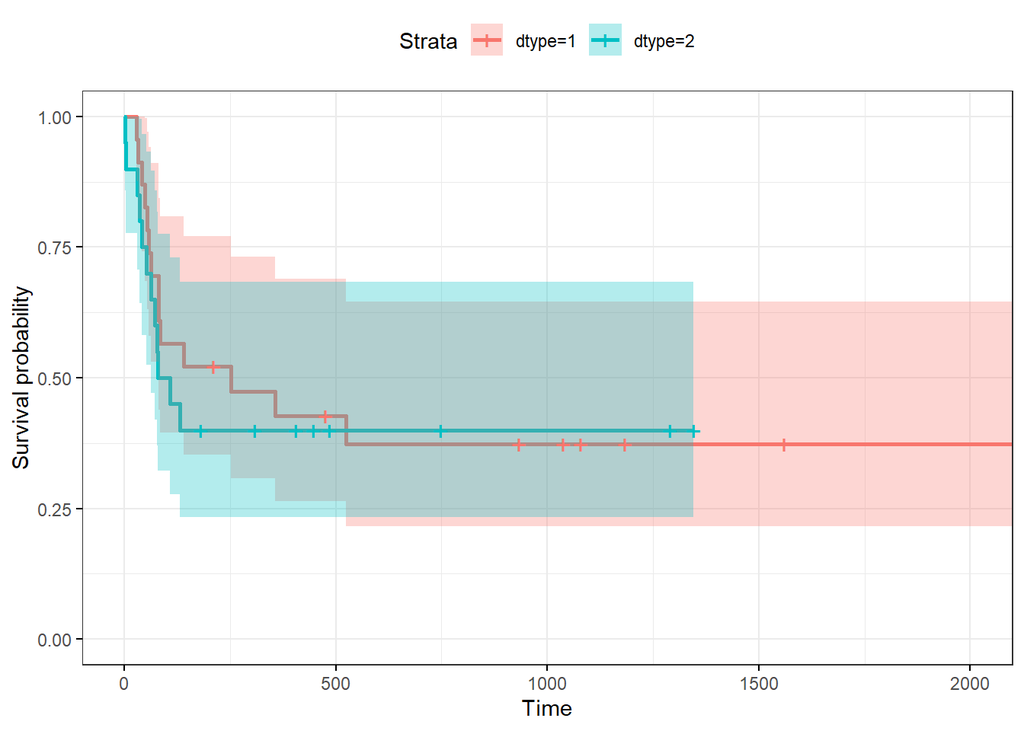

```r
ggsurvplot(fit4,
          conf.int = TRUE,
          risk.table.col = "strata", # Change risk table color by groups
          ggtheme = theme_bw()
)
```

#### 그래프를 보면 dtype에 따라 생존함수가 큰 차이를 보이고 있지는 않다고 판단된다. 그룹 간 생존함수가 교차하고 있으므로 Log-rank test 대신 Peto & Peto test 를 실시해보면 다음과 같다.

```r
survdiff(Surv(time,delta)~dtype,data=hodg,rho=1)
```

```
## Call:
## survdiff(formula = Surv(time, delta) ~ dtype, data = hodg, rho = 1)
##
##          N Observed Expected (O-E)^2/E (O-E)^2/V
## dtype=1 23     9.29    10.60     0.162     0.506
## dtype=2 20     9.16     7.85     0.218     0.506
##
##  Chisq= 0.5  on 1 degrees of freedom, p= 0.5
```

#### 분석결과 p-value의 값이 0.5이므로 유의수준 0.05보다 매우 크다. 따라서 Hodgkin 림프종 존재 여부에 따라 Kaplan-Meier 생존함수가 다르다고 말할 수 없다.